# Business Statistics Mid-Term Assessment IB94X0 2024-2025 #1

5594410

2024-10-31

### **CERTIFICATION OF ORIGINAL WORK**

This is to certify that the work I am submitting is my own. I am aware of the University of Warwick regulation concerning plagiarism and collusion.

No substantial part(s) of the work submitted here has also been submitted by me in other assessments for accredited courses of study, and I acknowledge that if this has been done an appropriate reduction in the mark I might otherwise have received will be made.

AI was used in the preparation of this work. It was used in the development of the code: It was used to provide example uses of functions or approaches to elements of the challenges which were then interpreted by me and modified to be applicable to this data/report.

### **PROJECT OVERVIEW**

This report helps the promoter make a decision regarding the placement of their stall to maximize attraction, performing the specific analyses requested.

1. Provide data integrity and quality check of the dataset.
2. Provide a summary table for each location that includes the first and last measurement dates, mean daily footfall, and the standard deviation, highest, and lowest daily footfall.
3. Provide a plot showing the distribution of footfall across all days in the dataset from the year 2019(pre-pandemic).
4. Perform a two sample t-test to compare the footfall on Coney Street to Stonegate.
5. Perform an additional two sample t-test to compare the footfall on Coney Street to Stonegate only on weekends (i.e. Saturdays/Sundays).
6. What would you advise the promoter about whether they should place their stall on Coney Street or Stonegate to maximize the number of passers by:
1. if they were doing so every day of the week
2. if they were doing so only at weekends.

### **DATA DICTIONARY**

This data comes from cameras that automatically measure the number of people who walk past a particular location. The variables are described in the table below

| Variable | Description |
| --- | --- |
| Date | Specific date of the recorded footfall data |
| SiteName | City where the footfall data was collected |
| LocationName | Specific street or location within sitename(i.e York) where footfall was recorded |
| WeekDay | Day of the week corresponding to each date |
| TotalCount | Recorded footfall at the specific location on the given date |
| Recording_ID | Unique identifier for each recording. |

# **SECTION 1**

### **Loading libraries for data manipulation, visualization and table styling**

```r
# Load necessary libraries
library(tidyverse)  # For data manipulation and visualization

# install.packages("kableExtra")  # Uncomment if kableExtra is not installed

library(kableExtra)  # For table styling

options(width=100)  # Set console output width
```

### **1. Loading of the dataset**

```r
 # Read the York footfall dataset
york_footfall <- read_csv("York_Footfall_data.csv")
# Display the first five rows of the dataset for an overview
head(york_footfall)
```

```
## # A tibble: 6 × 6
##   Date       SiteName LocationName             WeekDay  TotalCount Recording_ID
##   <date>     <chr>    <chr>                    <chr>         <dbl>        <dbl>
## 1 2015-01-01 York     Church Street            Thursday       1952       375836
## 2 2015-01-01 York     Coney Street             Thursday      12220       724862
## 3 2015-01-01 York     Micklegate               Thursday       5559       451020
## 4 2015-01-01 York     Parliament Street at M&S Thursday       7802       523989
## 5 2015-01-01 York     Stonegate                Thursday      14004       382272
## 6 2015-01-02 York     Church Street            Friday         3451       464381
```

### **2. Provide data integrity and quality check of the dataset**

```r
# 1. Displays the structure of a dataset, including information about its type, number of observations, variable names, data types, and a preview of the data in each variable.

str(york_footfall)
```

```
## spc_tbl_ [8,204 × 6] (S3: spec_tbl_df/tbl_df/tbl/data.frame)
##  $ Date        : Date[1:8204], format: "2015-01-01" "2015-01-01" "2015-01-01" ...
##  $ SiteName    : chr [1:8204] "York" "York" "York" "York" ...
##  $ LocationName: chr [1:8204] "Church Street" "Coney Street" "Micklegate" "Parliament Street at M&S" ...
##  $ WeekDay     : chr [1:8204] "Thursday" "Thursday" "Thursday" "Thursday" ...
##  $ TotalCount  : num [1:8204] 1952 12220 5559 7802 14004 ...
##  $ Recording_ID: num [1:8204] 375836 724862 451020 523989 382272 ...
##  - attr(*, "spec")=
##   .. cols(
##   ..   Date = col_date(format = ""),
##   ..   SiteName = col_character(),
##   ..   LocationName = col_character(),
##   ..   WeekDay = col_character(),
##   ..   TotalCount = col_double(),
##   ..   Recording_ID = col_double()
##   .. )
##  - attr(*, "problems")=<externalptr>
```

```r
#2. Check for duplicates in the dataset.

duplicates <- york_footfall %>%
  filter(duplicated(.) | duplicated(., fromLast = TRUE)) # Identify duplicate rows

print(duplicates) # Display duplicates if any
```

```
## # A tibble: 0 × 6
## # ℹ 6 variables: Date <date>, SiteName <chr>, LocationName <chr>, WeekDay <chr>, TotalCount <dbl>,
## #   Recording_ID <dbl>
```

```r
# 3. Check for missing values (NA) in the dataset

#Considering that TotalCount is deemed valid, the decision was made to retain the NA values in the RecordingID column. It is an assumption that these NA entries may represent instances of missed data rather than irrelevant information; therefore, no removal was implemented for this column.

missing_values <- colSums(is.na(york_footfall))

print(missing_values) # Show the number of missing values per column
```

```
##         Date     SiteName LocationName      WeekDay   TotalCount Recording_ID
##            0            0            0            0           10          100
```

```r
# Remove rows with missing values in "TotalCount" column
cleaned_york_footfall_dataset <- york_footfall %>%
  filter(!is.na(TotalCount))

print(cleaned_york_footfall_dataset) # Show cleaned dataset
```

```
## # A tibble: 8,194 × 6
##    Date       SiteName LocationName             WeekDay  TotalCount Recording_ID
##    <date>     <chr>    <chr>                    <chr>         <dbl>        <dbl>
##  1 2015-01-01 York     Church Street            Thursday       1952       375836
##  2 2015-01-01 York     Coney Street             Thursday      12220       724862
##  3 2015-01-01 York     Micklegate               Thursday       5559       451020
##  4 2015-01-01 York     Parliament Street at M&S Thursday       7802       523989
##  5 2015-01-01 York     Stonegate                Thursday      14004       382272
##  6 2015-01-02 York     Church Street            Friday         3451       464381
##  7 2015-01-02 York     Coney Street             Friday        31495       654292
##  8 2015-01-02 York     Micklegate               Friday         7055       965489
##  9 2015-01-02 York     Parliament Street at M&S Friday        25427       289782
## 10 2015-01-02 York     Stonegate                Friday        25678       687871
## # ℹ 8,184 more rows
```

```r
#4. Check the cleaned dataset for outliers

#Outliers in the locations were kept because they represented higher foot traffic during seasonal events, such as Christmas. This choice was made to preserve the dataset's integrity and ensure that the analysis accurately reflects visitor behavior without distorting the results.

footfall_outliers <- cleaned_york_footfall_dataset %>%
  group_by(LocationName) %>% # Groups the data by LocationName

  mutate( # Use mutate to add new variables based on the grouped data

    Q1 = quantile(TotalCount, 0.25, na.rm = TRUE), # Calculates the first quartile (Q1), ignoring NA values

    Q3 = quantile(TotalCount, 0.75, na.rm = TRUE), # Calculates the third quartile (Q3), ignoring NA values

    IQR = Q3 - Q1, # Calculates the interquartile range (IQR)

    lower_bound = Q1 - 1.5 * IQR,  # Calculates the lower bound for outliers (Q1 - 1.5 * IQR)

    upper_bound = Q3 + 1.5 * IQR, # Calculates the upper bound for outliers (Q3 + 1.5 * IQR)

    is_outlier = TotalCount < lower_bound | TotalCount > upper_bound # Identifies if each TotalCount observation is an outlier
  )

outliers <- footfall_outliers %>% filter(is_outlier) # Filter outliers

# Summarize outlier statistics by location
outlier_summary <- outliers %>%
  group_by(LocationName) %>%
  summarise(
    total_outliers = n()
  )

# Display the outliers across locations
print(outlier_summary)
```

```
## # A tibble: 6 × 2
##   LocationName             total_outliers
##   <chr>                             <int>
## 1 Church Street                        34
## 2 Coney Street                         71
## 3 Micklegate                           67
## 4 Parliament Street                    52
## 5 Parliament Street at M&S              5
## 6 Stonegate                            74
```

### **3. Provide a summary table for each location that includes the first and last measurement dates, mean daily footfall, and the standard deviation, highest, and lowest daily footfall**

```r
# Creating the summary table by grouping data based on Location

york_footfall_summary_table <- cleaned_york_footfall_dataset %>%
  group_by(LocationName) %>%  # Grouping by location name
  summarise(
    First_FootFall_Measurement_Date = min(Date),  # Earliest measurement date
    Last_Footfall_Measurement_Date = max(Date),    # Latest measurement date
    Mean_Daily_Footfall = mean(TotalCount, na.rm = TRUE),  # Mean daily footfall
    Std_Dev_Daily_Footfall = sd(TotalCount, na.rm = TRUE),  # Standard deviation
    Highest_Daily_Footfall = max(TotalCount, na.rm = TRUE), # Highest daily footfall
    Lowest_Daily_Footfall = min(TotalCount, na.rm = TRUE)   # Lowest daily footfall
  )

# Display the summary table

print(york_footfall_summary_table)
```

```
## # A tibble: 6 × 7
##   LocationName             First_FootFall_Measurement_D…¹ Last_Footfall_Measur…² Mean_Daily_Footfall
##   <chr>                    <date>                         <date>                               <dbl>
## 1 Church Street            2015-01-01                     2017-06-18                           4352.
## 2 Coney Street             2015-01-01                     2019-12-31                          23507.
## 3 Micklegate               2015-01-01                     2019-12-31                           7487.
## 4 Parliament Street        2015-06-08                     2019-12-31                          22631.
## 5 Parliament Street at M&S 2015-01-01                     2015-06-07                          22432.
## 6 Stonegate                2015-01-01                     2019-12-31                          19902.
## # ℹ abbreviated names: ¹First_FootFall_Measurement_Date, ²Last_Footfall_Measurement_Date
## # ℹ 3 more variables: Std_Dev_Daily_Footfall <dbl>, Highest_Daily_Footfall <dbl>,
## #   Lowest_Daily_Footfall <dbl>
```

### **4. Plotting the distribution of footfall for each location across all days in the dataset for the year 2019(Pre-COVID19)**

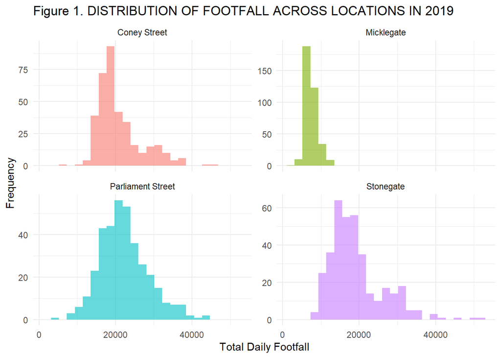

```r
#Filter the york footfall dataset for the year 2019(pre-covid19)

york_footfall_data_2019 <- cleaned_york_footfall_dataset %>% filter(year(Date) == 2019)


# Plot the histogram of footfall for each location based on the "york_footfall_data_2019" dataset

hist_2019_dataset <- ggplot(york_footfall_data_2019, aes(x = TotalCount, fill = LocationName)) +
  geom_histogram(bins = 25, alpha = 0.6) +
  facet_wrap(~ LocationName, scales = "free_y") +  # Separate plots for each location
  labs(title = "Figure 1. DISTRIBUTION OF FOOTFALL ACROSS LOCATIONS IN 2019",
       x = "Total Daily Footfall", y = "Frequency")  +  # Labeling of the plot and the axes
  theme_minimal() +
  theme(legend.position = "none")

print(hist_2019_dataset)
```

### **5. Perform a two sample t-test to compare the footfall on Coney Street to Stonegate.**

```r
# Filter the data for everyday of the week and the two locations of interest(Coney Street and Stonegate)

coney_street <- york_footfall_data_2019 %>% filter(LocationName == "Coney Street") %>% select(TotalCount) # Subset data for Coney Street

# Subset data for Stonegate
stonegate <- york_footfall_data_2019 %>% filter(LocationName == "Stonegate") %>% select(TotalCount)

# Perform two sample t-test to compare the mean footfall between Coney Street and Stonegate for everyday of the week
all_days_t_test_result <- t.test(coney_street$TotalCount, stonegate$TotalCount)

# Print the results of the t-test
print(all_days_t_test_result)  # Output includes t-statistic, degrees of freedom, p-value, and confidence interval
```

```
##
##  Welch Two Sample t-test
##
## data:  coney_street$TotalCount and stonegate$TotalCount
## t = 3.3611, df = 699.18, p-value = 0.0008186
## alternative hypothesis: true difference in means is not equal to 0
## 95 percent confidence interval:
##   670.9189 2555.7989
## sample estimates:
## mean of x mean of y
##  20817.45  19204.09
```

### **6. Perform an additional two sample t-test to compare the footfall on Coney Street to Stonegate only on weekends (i.e. Saturdays/Sundays).**

```r
# Filter the data for weekends (Saturday and Sunday) and the two locations of interest(Coney Street and Stonegate)

weekend_york_footfall_data <- york_footfall_data_2019 %>%
  filter(WeekDay %in% c("Saturday", "Sunday") & LocationName %in% c("Coney Street", "Stonegate"))

# Perform an independent two-sample t-test, compare the mean footfall of Coney Street and Stonegate during weekends

weekend_t_test_result <- t.test(TotalCount ~ LocationName, data = weekend_york_footfall_data)

# Print the results of the t-test
print(weekend_t_test_result)  # Output includes t-statistic, degrees of freedom, p-value, and confidence interval
```

```
##
##  Welch Two Sample t-test
##
## data:  TotalCount by LocationName
## t = -0.29072, df = 203.88, p-value = 0.7716
## alternative hypothesis: true difference in means between group Coney Street and group Stonegate is not equal to 0
## 95 percent confidence interval:
##  -2362.601  1755.409
## sample estimates:
## mean in group Coney Street    mean in group Stonegate
##                   25863.37                   26166.96
```

## **SECTION 2**

### **YORK FOOTFALL ANALYSIS REPORT**

The report begins with an overview of foot traffic across all York locations, which includes the first and last dates of measurement, average daily footfall, standard deviation, and the range between the highest and lowest recorded daily footfall (see Table 1).

```r
kable(york_footfall_summary_table, caption = "Table 1. SUMMARY OF FOOTFALL DISTRIBUTION ACROSS LOCATIONS IN YORK") %>%
  kable_styling(
    bootstrap_options = c("striped", "hover", "condensed"),
    full_width = F,
    position = "left",
    font_size = 12,
    latex_options = c("striped", "hold_position")
  ) %>%
  column_spec(1) %>%
  column_spec(2) %>%
  column_spec(3, background = "#f7f7f7") %>%
  row_spec(0, bold = TRUE, background = "#d9edf7", color = "#31708f")
```

Table 1. SUMMARY OF FOOTFALL DISTRIBUTION ACROSS LOCATIONS IN YORK

| LocationName | First_FootFall_Measurement_Date | Last_Footfall_Measurement_Date | Mean_Daily_Footfall | Std_Dev_Daily_Footfall | Highest_Daily_Footfall | Lowest_Daily_Footfall |
| --- | --- | --- | --- | --- | --- | --- |
| Church Street | 2015-01-01 | 2017-06-18 | 4352.429 | 1388.959 | 26848 | 402 |
| Coney Street | 2015-01-01 | 2019-12-31 | 23507.291 | 6608.089 | 51050 | 2960 |
| Micklegate | 2015-01-01 | 2019-12-31 | 7486.890 | 4800.012 | 98180 | 1309 |
| Parliament Street | 2015-06-08 | 2019-12-31 | 22631.379 | 6610.363 | 53749 | 1227 |
| Parliament Street at M&S | 2015-01-01 | 2015-06-07 | 22432.234 | 7749.681 | 53057 | 7802 |
| Stonegate | 2015-01-01 | 2019-12-31 | 19901.796 | 17826.401 | 328310 | 1297 |

#### **Footfall Distribution Overview (Pre-Pandemic)**

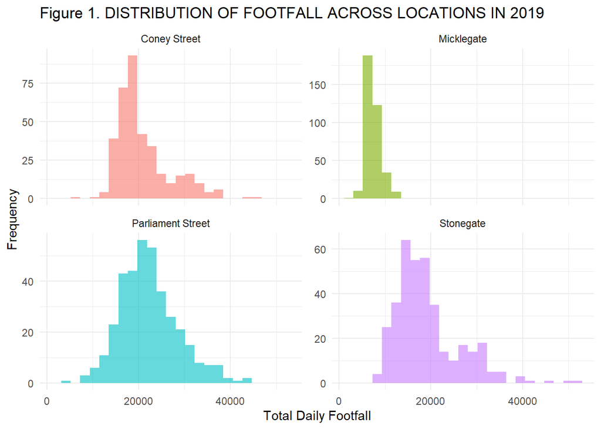

```r
print(hist_2019_dataset)
```

#### **Daily and Weekend Comparison of Coney Street and Stonegate**

The t-test analysis indicates that Coney Street’s average footfall (20,817) is significantly higher than that of Stonegate (19,204), with a 95% confidence interval ranging from 671 to 2,556 (t = 3.36, p = 0.0008). This highlights Coney Street as the better choice for maximizing daily exposure.

On the other hand, a separate analysis of weekend foot traffic shows that both locations are statistically comparable (t = -0.29, p = 0.77), with similar averages (Coney Street: 25,863; Stonegate: 26,167). This suggests that either location would work well for attracting visitors on weekends.

#### **Conclusion**

**Coney Street is the ideal choice for continuous operations throughout the week, thanks to its higher foot traffic and better visibility. On weekends, both Coney Street and Stonegate attract similar crowds, making either location a strong option for placement.** Overall, both spots have great potential to draw in visitors.